# Supplementary Information: Models

Laura Geronimo

## Full Sample Diagnostics

##M0 Stepwise regression on full model - all variables

Here I add all variables to the regression model and then apply stepwise AIC to see what variables are selected

### Examining model chosen via stepwise

#### Examining variables for multicolinearity: Corr matrix and Vif test on non FE vars

```
##                 TotPop_W_10k                        fHisp
##                    24.927558                     1.222333
##                 MHIadj_W_10k                MHVadj_W_100k
##                     2.736019                     4.537955
##                  TotHU_W_10k                    fS2ndHome
##                    28.107324                     1.178322
##              TaxBaseEst_1B_W                   ZCTA_shore
##                     6.933857                     1.201278
##         count_fema_sfha_W_1k        NFIP_ICCadj_YOLZ_W_1M
##                     1.420702                     1.368264
## IHP_fldDamAmountAdjDNZ_W_10M
##                     1.316421
```

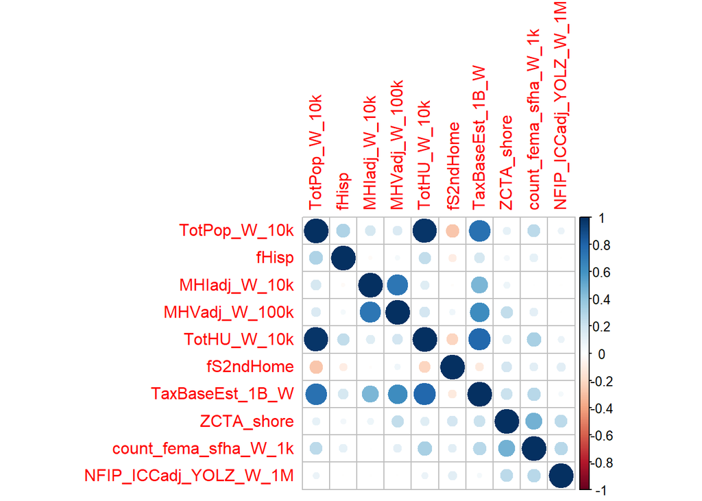

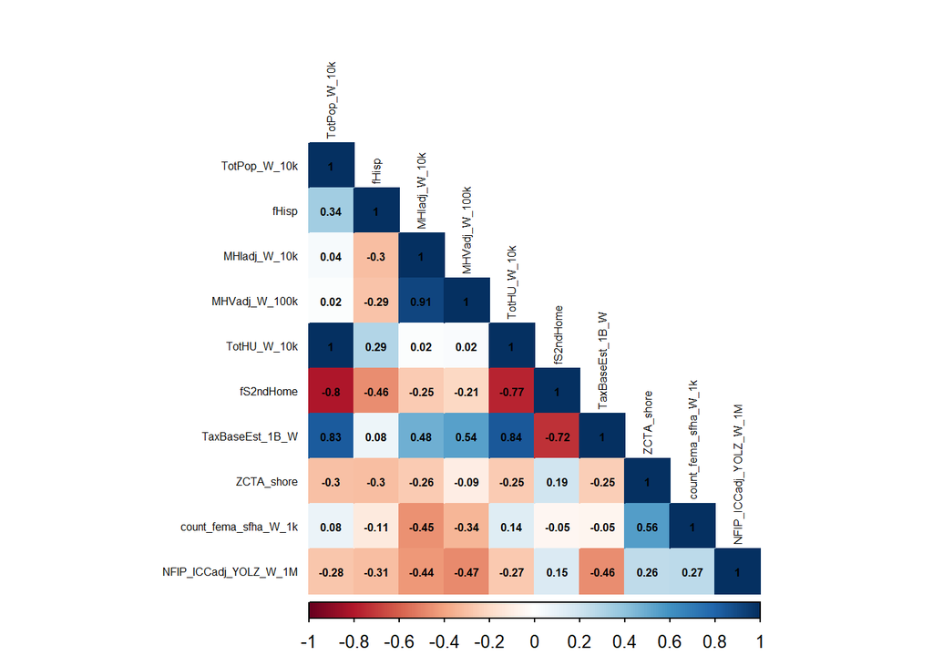

The VIF test indicates inflated VIF on TotPop, TotHU, MHV, MHI, and Tax Base. The correlation matrix indicates corr between: -TotPop: and TotHU (1), and fs2ndHome (-0.8), and Taxbase (0.83) -MHI: and MHV (0.91) -TotHU: and TotPop (1), and -fs2ndHome: and tot HU (-0.77), and taxBase (-0.72)

### SVSS test

Running SVSS test to see which variables are included

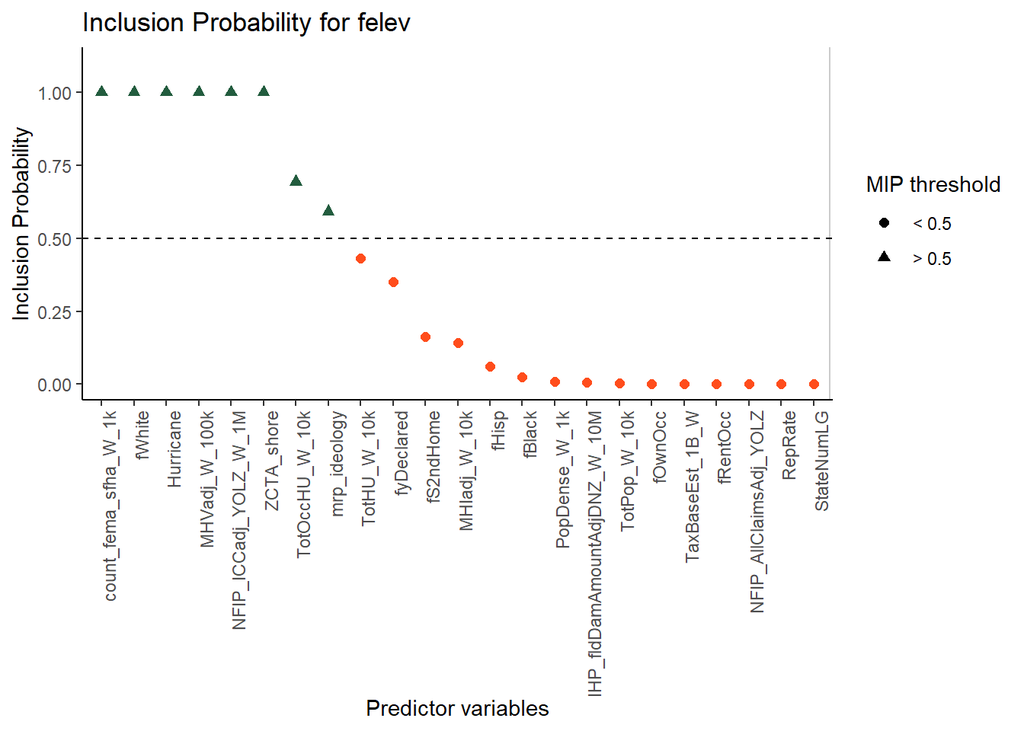

#### Logistic model comparing original Dissertation model with SVSS predictors

##Correlation Matrices on select vars Note that in preparation for modeling, we examine all of the variables recommended in the SVSS test, plus variables that were significant in the Chi-Square and Anova tests, and are relevant to the literature based on domain knowledge.

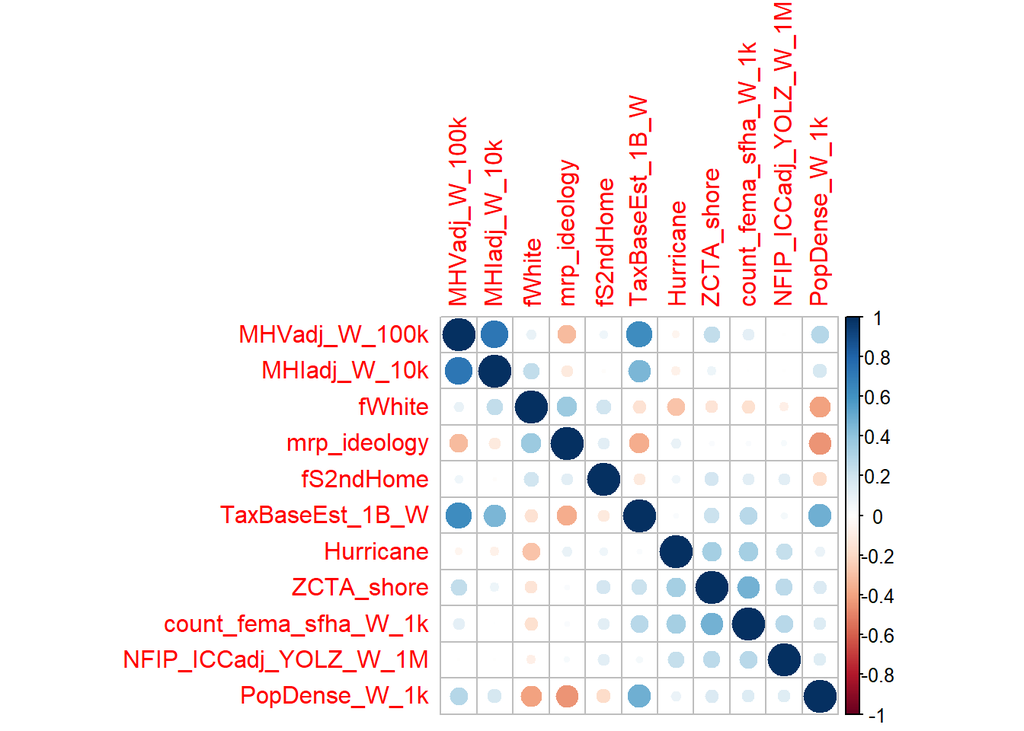

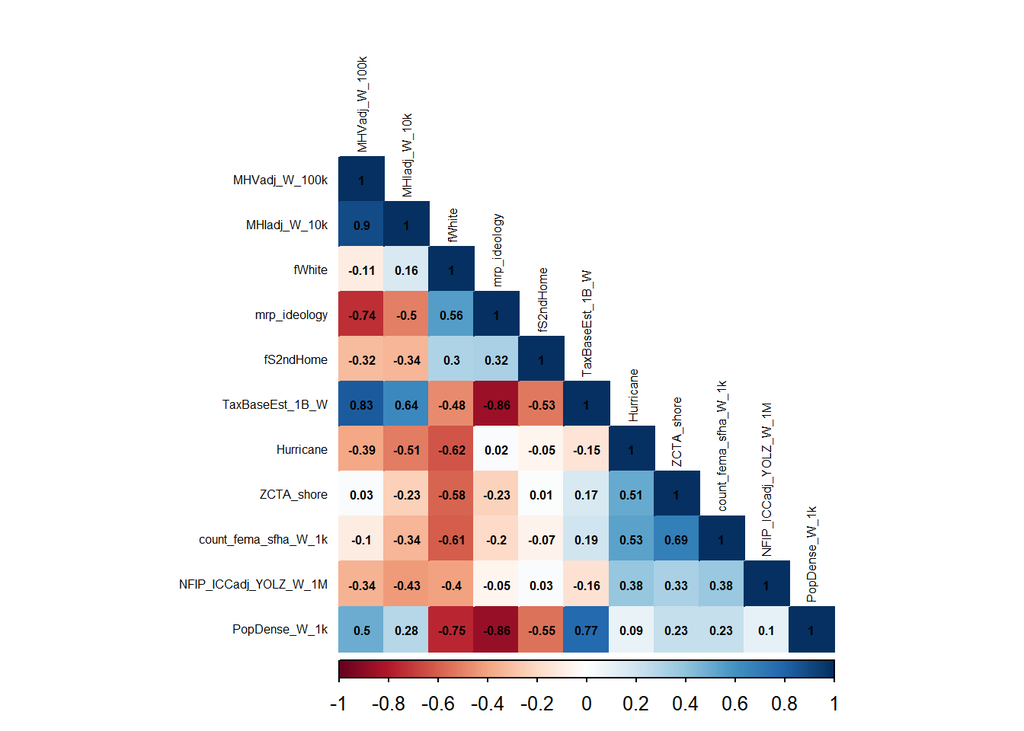

Given the high correlation between MHV and MHI, we drop MHI.

Note that there is significant correlation between several variables of interest, including MPR, MHV, tax base, fWhite, and population density.

Going to have to select specific hypotheses to test one at a time.

##Stepwise Regression for specific hypotheses

## Model 1: Race and Income

Model 1: testing race and income MHV, fWhite, MHV*fWhite, ZCTA_Shore Hurricane Count_FEMA NFIP_ICC Pop_Dense

##### Correlation Matrices for M1

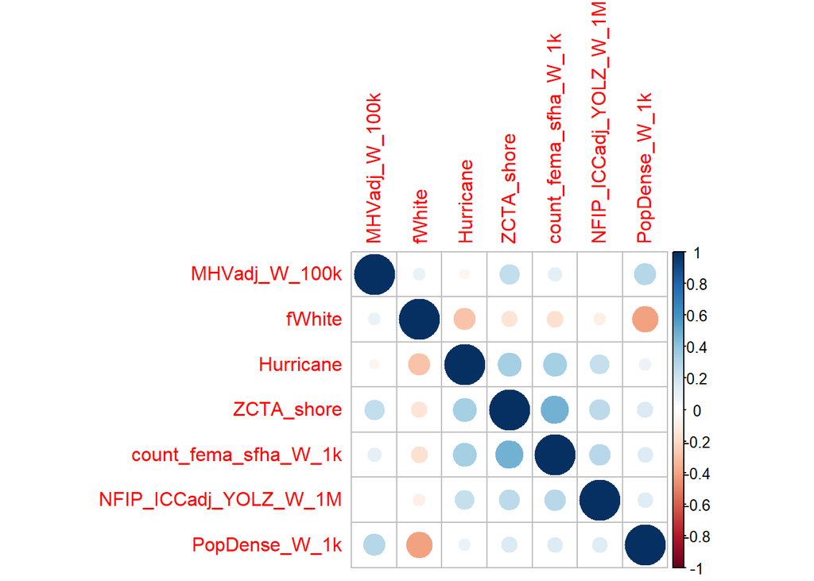

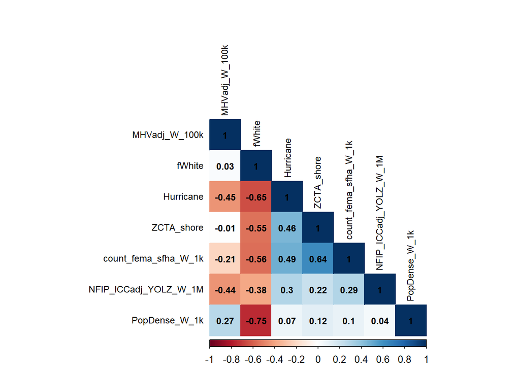

Note that there is high cor between: - fWhite and popdense(-0.75) - fWhite and hurricane (-0.65) - Count_FEMA and ZCTAShore (0.64)

Including all for the moment to check VIF

##### M1 - Full model with fixed effects & select vars

**Logit Model 1B: Full sample (testing Race and MHV**

|  | *Dependent variable:* |
| --- | --- |
|  | odds Ratio of felev |
| MHV (100k W) | 0.83 |
|  | (0.19) |
| Fraction White | 1.04 |
|  | (0.39) |
| Shoreline ZCTA | 4.71*** |
|  | (0.11) |
| Count of HUs in FEMA SFHA 1k (W) | 1.19*** |
|  | (0.03) |
| NFIP ICC Claims 1M (W) by ZCTA-YOL | 1.48*** |
|  | (0.12) |
| Population Density 1k (W) | 0.95 |
|  | (0.03) |
| MHV:Fraction White interaction | 1.59** |
|  | (0.22) |
| Constant | 0.00 |
|  | (3,503.48) |
| State FE | YES |
| Year FE | YES |
| Pseudo R2 | 0.47 |
| Observations | 5,658 |
| Log Likelihood | -1,617.96 |
| Akaike Inf. Crit. | 3,413.92 |
| *Note:* | p<0.1; p<0.05; p<0.01 |

##### Model Series A.0: Single variable model with FE for all explanatory vars:

**Logit Model Comparison: Single Variable Mode**

|  | *Dependent variable:* |  |  |  |  |  |  |  |
| --- | --- | --- | --- | --- | --- | --- | --- | --- |
|  | odds Ratio of felev |  |  |  |  |  |  |  |
|  | (1) | (2) | (3) | (4) | (5) | (6) | (7) | (8) |
| MHV (100k W) |  | 1.43*** |  |  |  |  |  | 0.94 |
|  |  | (0.04) |  |  |  |  |  | (0.17) |
| Fraction White |  |  | 3.53*** |  |  |  |  | 1.30 |
|  |  |  | (0.21) |  |  |  |  | (0.36) |
| Shoreline ZCTA |  |  |  | 6.45*** |  |  |  |  |
|  |  |  |  | (0.10) |  |  |  |  |
| Count of HUs in FEMA SFHA 1k (W) |  |  |  |  | 1.42*** |  |  |  |
|  |  |  |  |  | (0.03) |  |  |  |
| NFIP ICC Claims 1M (W) by ZCTA-YOL |  |  |  |  |  | 2.32*** |  |  |
|  |  |  |  |  |  | (0.12) |  |  |
| Population Density 1k (W) |  |  |  |  |  |  | 1.00 |  |
|  |  |  |  |  |  |  | (0.03) |  |
| MHV:Fraction White interaction |  |  |  |  |  |  |  | 1.61** |
|  |  |  |  |  |  |  |  | (0.20) |
| Constant | 0.00 | 0.00 | 0.00 | 0.00 | 0.00 | 0.00 | 0.00 | 0.00 |
|  | (3,454.33) | (3,425.01) | (3,426.37) | (3,526.15) | (3,481.96) | (3,460.65) | (3,454.32) | (3,406.73) |
| State FE | YES | YES | YES | YES | YES | YES | YES | YES |
| Year FE | YES | YES | YES | YES | YES | YES | YES | YES |
| Pseudo R2 | 0.38 | 0.4 | 0.39 | 0.45 | 0.42 | 0.39 | 0.38 | 0.4 |
| Observations | 5,658 | 5,658 | 5,658 | 5,658 | 5,658 | 5,658 | 5,658 | 5,658 |
| Log Likelihood | -1,876.06 | -1,839.69 | -1,857.04 | -1,672.39 | -1,779.95 | -1,846.44 | -1,876.07 | -1,826.82 |
| Akaike Inf. Crit. | 3,916.13 | 3,845.38 | 3,880.09 | 3,510.78 | 3,725.89 | 3,858.87 | 3,918.13 | 3,823.64 |
| *Note:* | p<0.1; p<0.05; p<0.01 |  |  |  |  |  |  |  |

##### Model Series A.1 (Starting with best model from above and dropping vars)

**Logit Model Comparison: Full Sample, Dropping variables**

[output not shown]

The model above confirms that the stepwise process selected the model with the lowest AIC

##### Post Tests M1

##### Examining outliers and leverage points

###### Diagnostics:

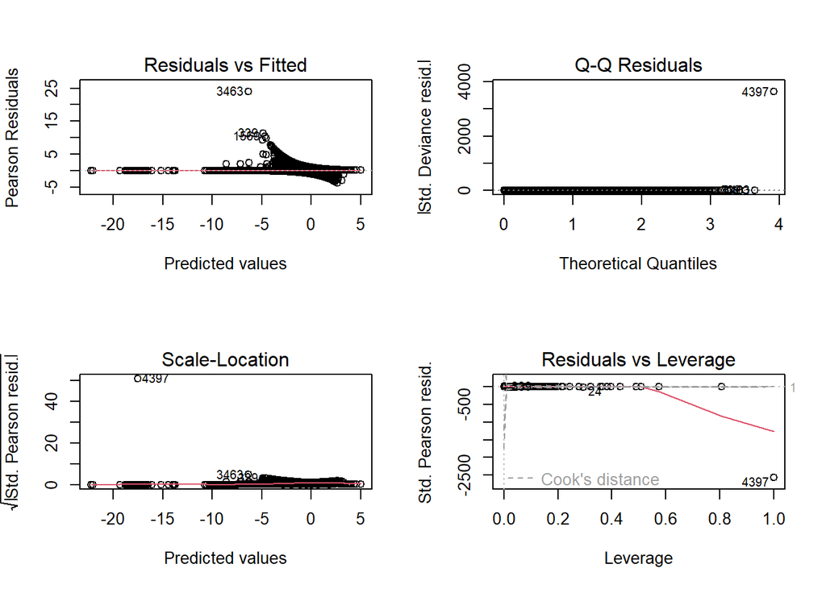

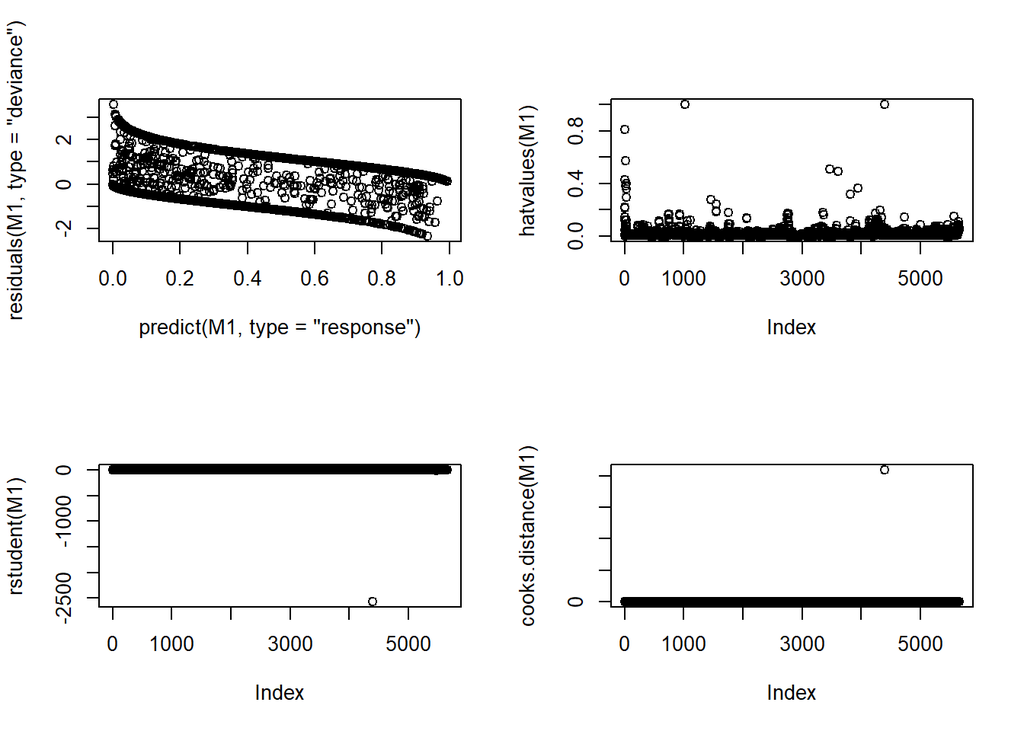

```
##       rstudent unadjusted p-value Bonferroni p
## 4397 -2572.152                  0            0
```

######Identifying influential observations

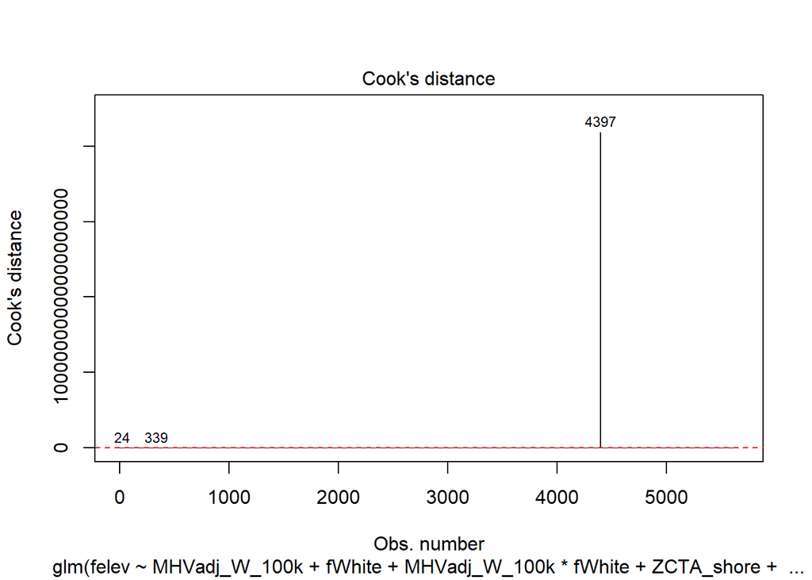

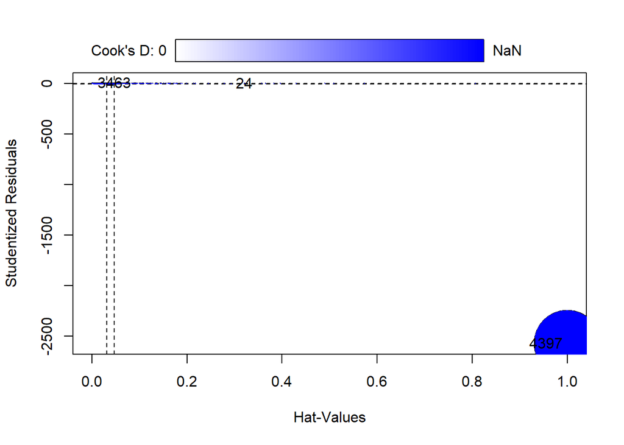

```
##           StudRes         Hat                         CookD
## 24      -1.956623 0.293336949                    0.01845292
## 1025          NaN 1.000000000                           NaN
## 3463     3.726420 0.002033153                    0.01319971
## 4397 -2572.151765 1.000000000 20923915851345616896.00000000
```

##### Drawing predicted probabilities

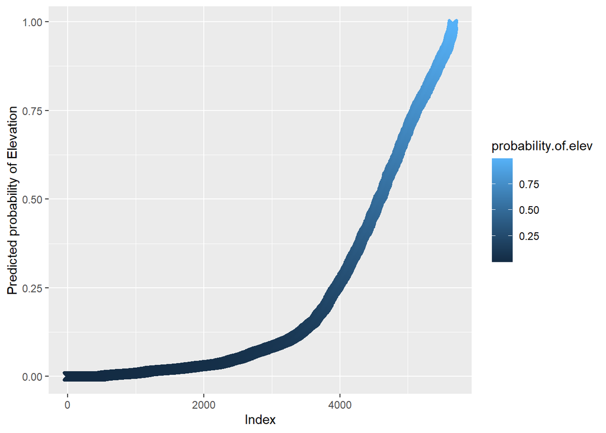

##### Cross validation

###### Confusion matrix

```
## Confusion Matrix and Statistics
##
##           Reference
## Prediction Acqui Elev
##      Acqui   796   67
##      Elev     37  155
##
##                Accuracy : 0.9014
##                  95% CI : (0.8818, 0.9187)
##     No Information Rate : 0.7896
##     P-Value [Acc > NIR] : < 0.0000000000000002
##
##                   Kappa : 0.6879
##
##  Mcnemar's Test P-Value : 0.00446
##
##             Sensitivity : 0.9556
##             Specificity : 0.6982
##          Pos Pred Value : 0.9224
##          Neg Pred Value : 0.8073
##              Prevalence : 0.7896
##          Detection Rate : 0.7545
##    Detection Prevalence : 0.8180
##       Balanced Accuracy : 0.8269
##
##        'Positive' Class : Acqui
##
```

### M1_Unlev: Dropping leverage points and rerunning model

**Logit Model Comparison: Dropping Influential Observations**

|  | *Dependent variable:* |
| --- | --- |
|  | Odds Ratio of felev |
| MHV (100k W) | 0.825 |
|  | (0.192) |
| Fraction White | 1.003 |
|  | (0.391) |
| Shoreline ZCTA | 4.725*** |
|  | (0.107) |
| Count of HUs in FEMA SFHA 1k (W) | 1.187*** |
|  | (0.030) |
| NFIP ICC Claims 1M (W) by ZCTA-YOL | 1.483*** |
|  | (0.121) |
| Population Density 1k (W) | 0.945 |
|  | (0.035) |
| MHV:Fraction White interaction | 1.615** |
|  | (0.222) |
| 2 | 0.000 |
|  | (5,774.686) |
| State FE | Yes |
| Year FE | Yes |
| Pseudo R2 | 0.48 |
| Observations | 5,653 |
| Log Likelihood | -1,602.826 |
| Akaike Inf. Crit. | 3,379.653 |
| *Note:* | p<0.1; p<0.05; p<0.01 |

##### Post Tests M1_unLev

##### Examining outliers and leverage points

###### Diagnostics

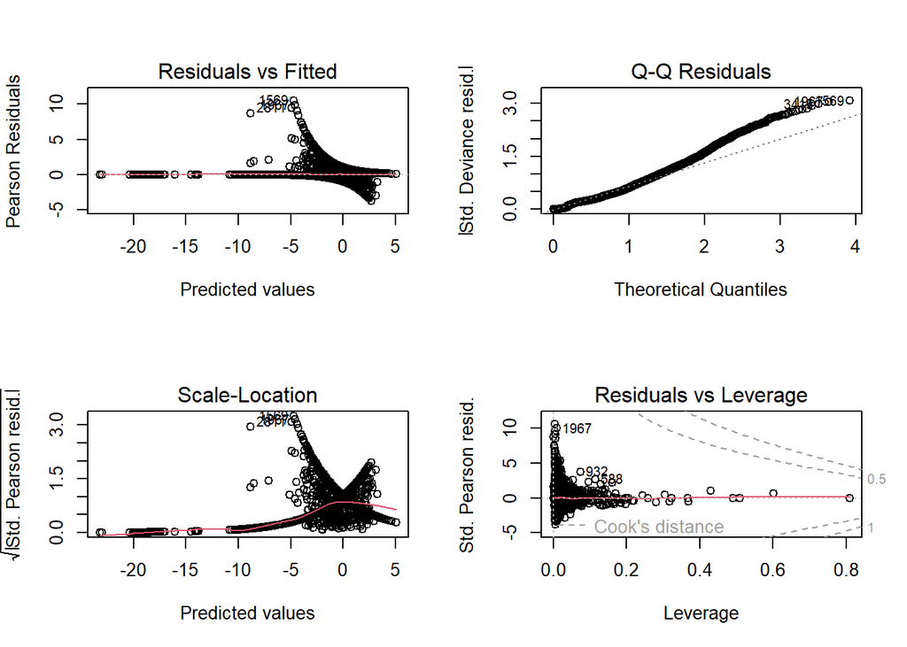

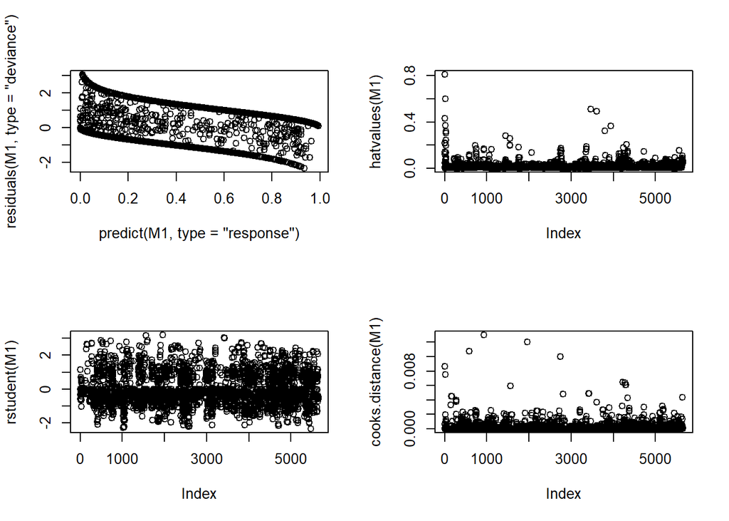

```
## No Studentized residuals with Bonferroni p < 0.05
## Largest |rstudent|:
##      rstudent unadjusted p-value Bonferroni p
## 1967 3.197115          0.0013881           NA
```

######Identifying influential observations

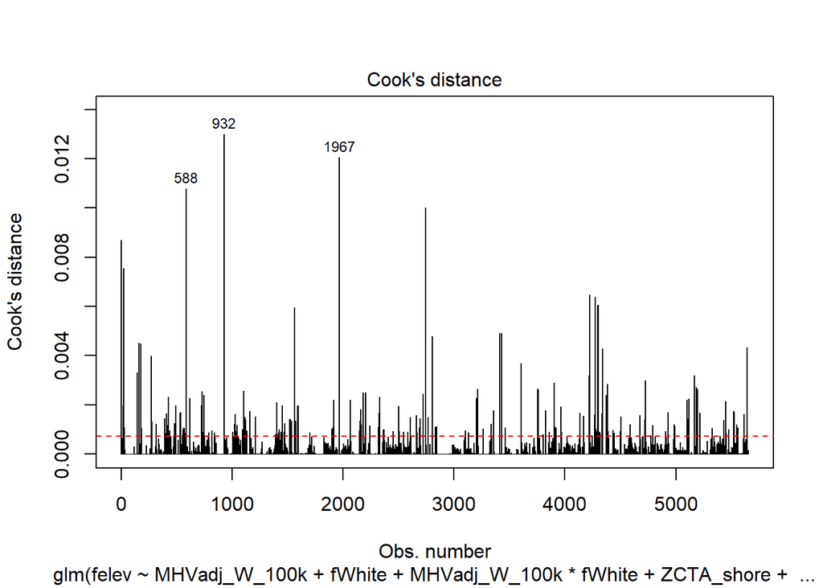

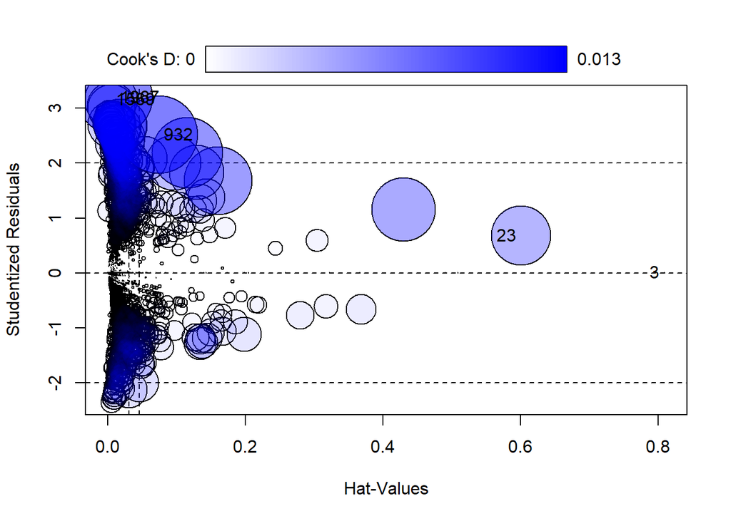

```
##            StudRes         Hat             CookD
## 3    -0.0003925317 0.809475405 0.000000006320399
## 23    0.6807760004 0.601025918 0.007553002316945
## 932   2.5163934790 0.074308470 0.013005009619072
## 1569  3.1540786364 0.004642516 0.005963043439825
## 1967  3.1971149329 0.010519282 0.012060400258903
```

###### Drawing predicted probabilities

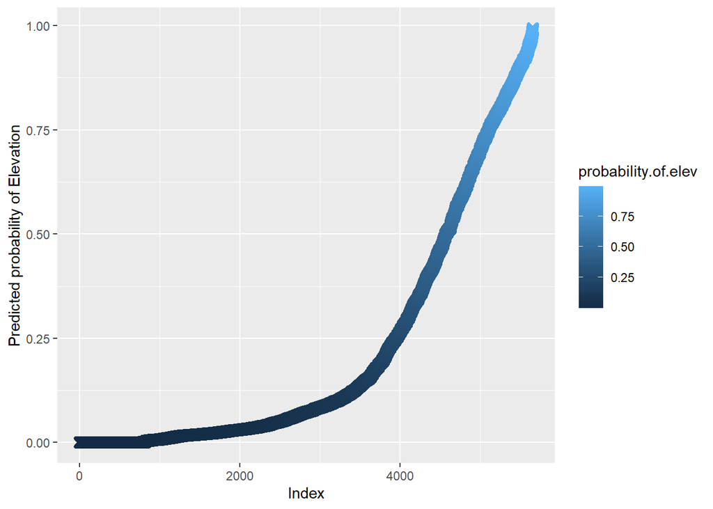

##### Cross validation

###### Confusion Matrix

```
## Confusion Matrix and Statistics
##
##           Reference
## Prediction Acqui Elev
##      Acqui   817   54
##      Elev     38  145
##
##                Accuracy : 0.9127
##                  95% CI : (0.894, 0.9291)
##     No Information Rate : 0.8112
##     P-Value [Acc > NIR] : <0.0000000000000002
##
##                   Kappa : 0.706
##
##  Mcnemar's Test P-Value : 0.1179
##
##             Sensitivity : 0.9556
##             Specificity : 0.7286
##          Pos Pred Value : 0.9380
##          Neg Pred Value : 0.7923
##              Prevalence : 0.8112
##          Detection Rate : 0.7751
##    Detection Prevalence : 0.8264
##       Balanced Accuracy : 0.8421
##
##        'Positive' Class : Acqui
##
```

## Model 2: MPR Ideology (conservative ideology)

##### Correlation Matrices for M2

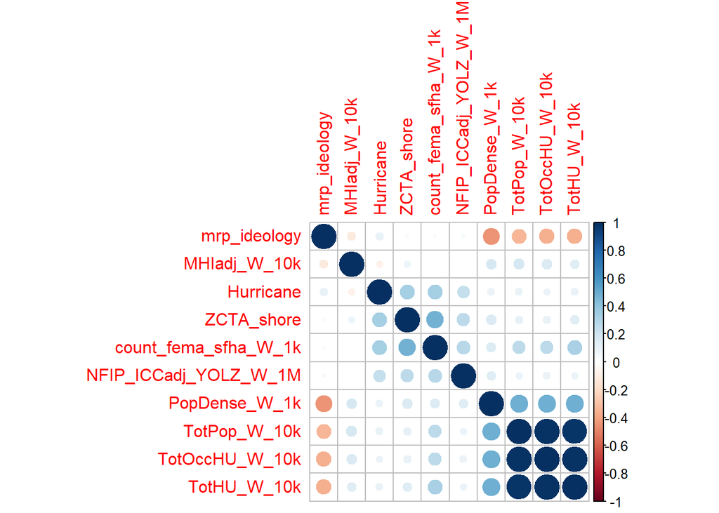

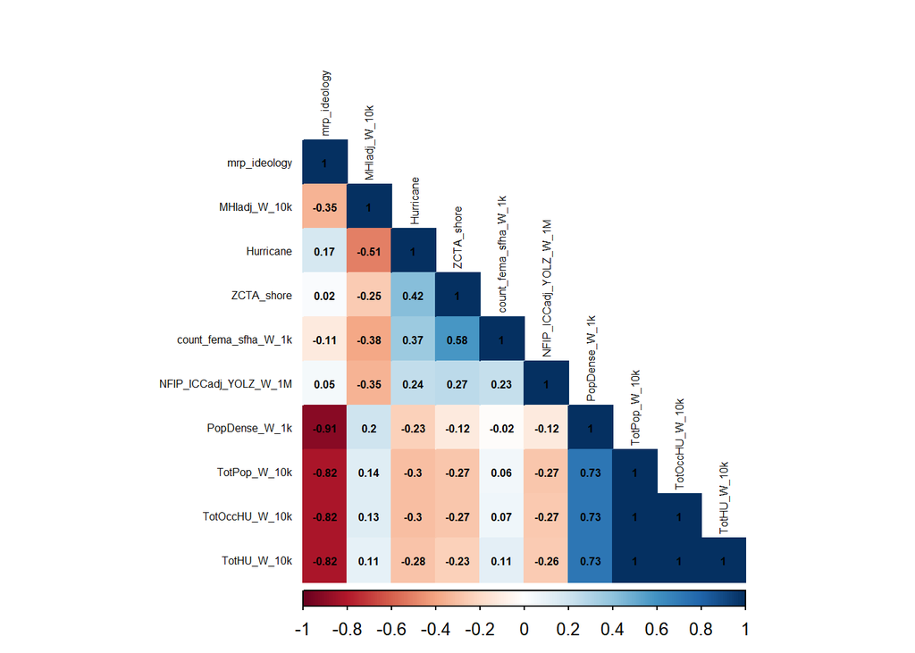

### Model 2: MPR Ideology

Model 2: testing MPR IDeology MPR Ideology, ZCTA_Shore Hurricane Count_FEMA NFIP_ICC

##### M2

##### Stepwise regression using AIC

**Logit Model Series 2: Full sample (testing Political Ideology)**

[output not shown]

##### Model Series A.0: Single variable model with FE for all explanatory vars:

**Logit Model Comparison: Single Variable Mode**

|  | *Dependent variable:* |  |  |  |  |
| --- | --- | --- | --- | --- | --- |
|  | odds Ratio of felev |  |  |  |  |
|  | (1) | (2) | (3) | (4) | (5) |
| Conservative Ideology |  | 2.14*** |  |  |  |
|  |  | (0.20) |  |  |  |
| Shoreline ZCTA |  |  | 6.47*** |  |  |
|  |  |  | (0.10) |  |  |
| Count of HUs in FEMA SFHA 1k (W) |  |  |  | 1.42*** |  |
|  |  |  |  | (0.03) |  |
| NFIP ICC Claims 1M (W) by ZCTA-YOL |  |  |  |  | 2.32*** |
|  |  |  |  |  | (0.12) |
| Constant | 0.00 | 0.00 | 0.00 | 0.00 | 0.00 |
|  | (3,453.59) | (3,457.81) | (5,812.40) | (5,739.44) | (3,459.89) |
| State FE | YES | YES | YES | YES | YES |
| Year FE | YES | YES | YES | YES | YES |
| Pseudo R2 | 0.39 | 0.39 | 0.46 | 0.42 | 0.4 |
| Observations | 5,653 | 5,653 | 5,653 | 5,653 | 5,653 |
| Log Likelihood | -1,861.52 | -1,854.13 | -1,657.54 | -1,765.44 | -1,831.93 |
| Akaike Inf. Crit. | 3,883.03 | 3,870.26 | 3,477.08 | 3,692.88 | 3,825.86 |
| *Note:* | p<0.1; p<0.05; p<0.01 |  |  |  |  |

##### Post Tests M2_unLev

##### Examining outliers and leverage points

###### Diagnostics

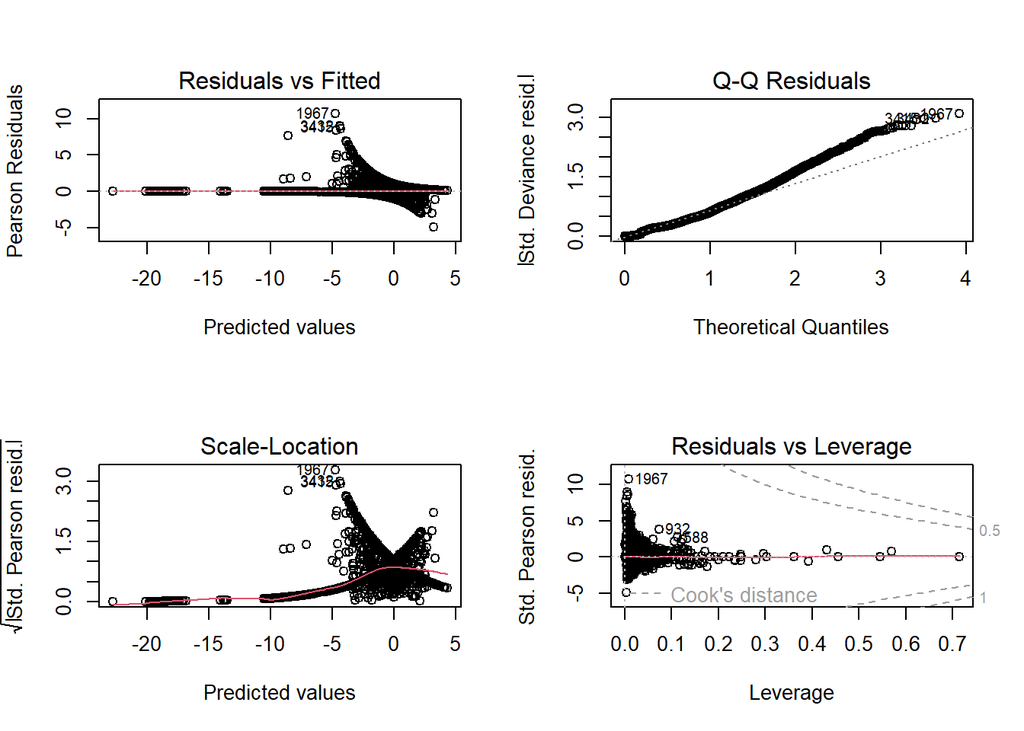

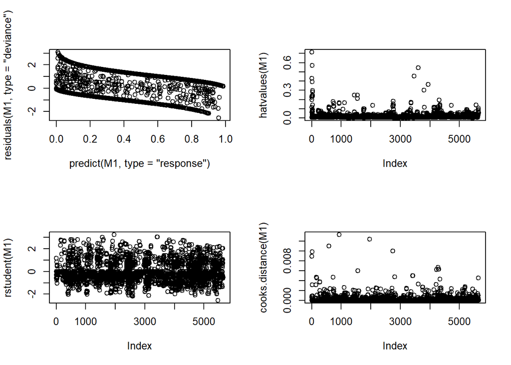

```
## No Studentized residuals with Bonferroni p < 0.05
## Largest |rstudent|:
##      rstudent unadjusted p-value Bonferroni p
## 1967 3.245789          0.0011713           NA
```

#identifying influential observations (p.196)

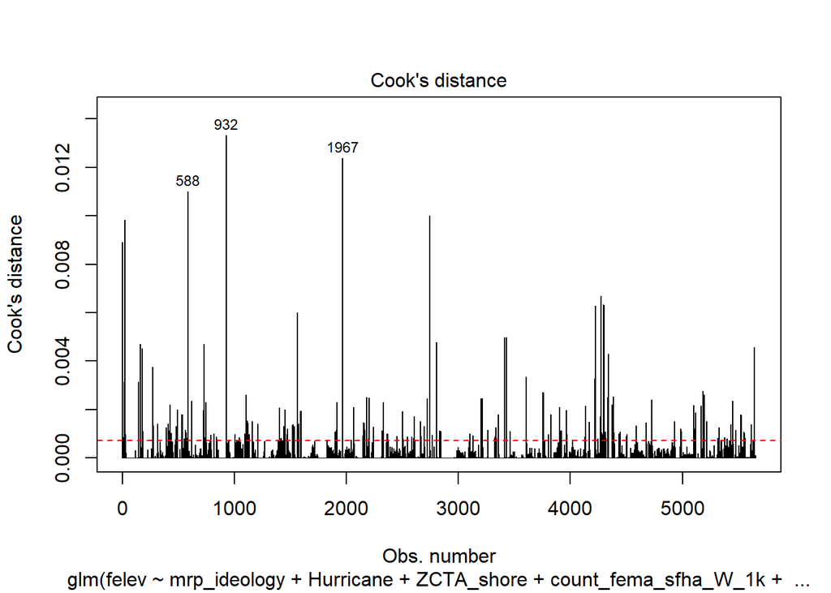

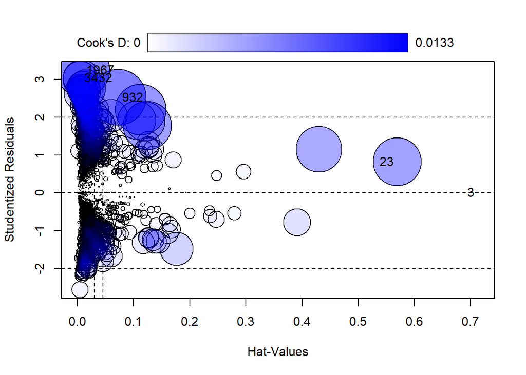

```
##            StudRes         Hat             CookD
## 3    -0.0003040514 0.713842058 0.000000002109489
## 23    0.8195817773 0.569910338 0.009828860713476
## 932   2.5253274766 0.072946348 0.013327675074860
## 1967  3.2457888890 0.009046177 0.012373859796538
## 3432  3.0364352163 0.005219545 0.004987636788523
```

##### Drawing predicted probabilities

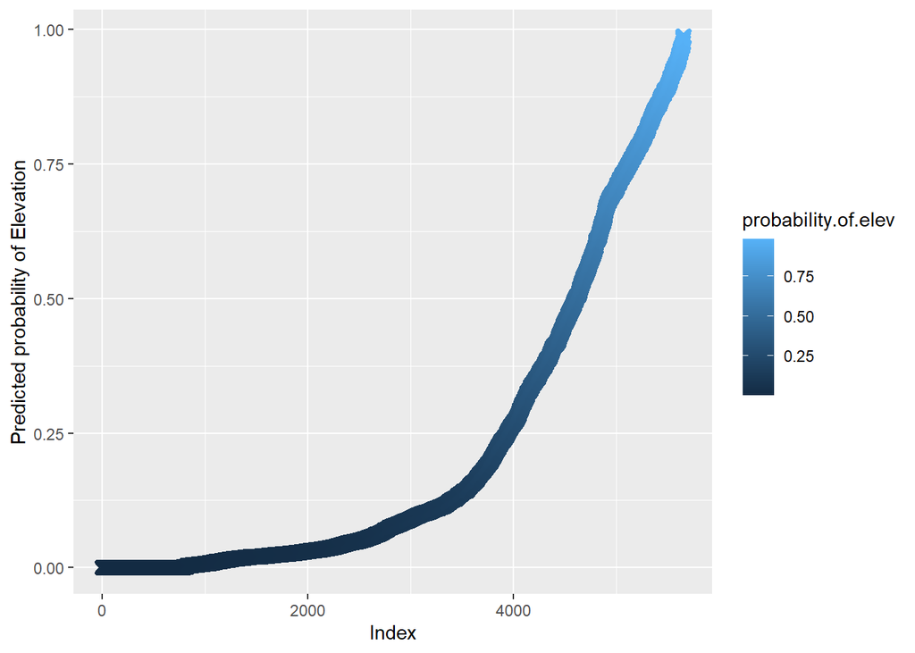

##### Cross validation

###### Confusion Matrix

```
## Confusion Matrix and Statistics
##
##           Reference
## Prediction Acqui Elev
##      Acqui   822   57
##      Elev     33  142
##
##                Accuracy : 0.9146
##                  95% CI : (0.8961, 0.9308)
##     No Information Rate : 0.8112
##     P-Value [Acc > NIR] : < 0.0000000000000002
##
##                   Kappa : 0.7077
##
##  Mcnemar's Test P-Value : 0.01533
##
##             Sensitivity : 0.9614
##             Specificity : 0.7136
##          Pos Pred Value : 0.9352
##          Neg Pred Value : 0.8114
##              Prevalence : 0.8112
##          Detection Rate : 0.7799
##    Detection Prevalence : 0.8340
##       Balanced Accuracy : 0.8375
##
##        'Positive' Class : Acqui
##
```